# Wine Recommendation Final, by Santiago, Erick, Dhruv, Aonia

# Wine Recommendations: General Explanation

### Overview and Motivation: Provide an overview of the project goals and the motivation for it. Consider that this will be read by people who did not see your project proposal.

Wine making is both a science and an art. Chemical characteristics affect the taste and can make a wine good or bad. However, there is a poetic side to wine: each wine can have notes and fragrances that can remind us of wood, fruits, raspberry, licorice… and this is where individual taste and a specific mood comes into play.Our project aimed to explore both aspects: the chemical one by building a model to predict wine quality from chemical properties like acidity, phenols, etc.; and the poetic one, by creating a recommendation system for any wine enthusiast to be able to search for wines with certain taste or fragrance notes.

### Related Work: Anything that inspired you, such as a paper, a web site, or something we discussed in class.

We wanted to explore predictive models, as well as natural language processing. We were familiar with apps like Vivino that can recommend wine, and wanted to do a variation on that, which also takes into consideration the chemical composition that makes a good wine.

### Initial Questions: What questions are you trying to answer? How did these questions evolve over the course of the project? What new questions did you consider in the course of your analysis?

What makes a good wine? This question drove the bulk of our analyses, eventually leading us to utilize both ordinal logistic regressions and random forests for predictive analysis of the wine qualities. Important facets of a wine were determined through traditional regression and machine learning techniques, and were thus incorporated into our final results for what makes a wine great. This question remained constant throughout our various analyses.

For the wine recommender idea, our main goal was to create a Shiny app where a user could specify a price range, and some keywords for the wine description. Initially we thought of allowing the user to specify a score, but then decided that we would just display the wines with the highest scores: everything else being equal, who wouldn’t a priori prefer a wine with a higher score? There were two changes that we decided during the course of the project: first we had planned to display some words from the description according to their frequency, but ended up doing something else instead. We thought it would be interesting to show the relative frequency of wines meeting the user criteria by country, so we added this as a visualization.

### Data: Source, scraping method, cleanup, etc.

We found the data set in a Kaggle repository. Wehad to download it and clean it. The cleanup consisted of removing rows with missing values for variables we wanted to use. The remaining data set after cleaning and wrangling the data was still large (>7k) giving us power to both determine what makes a good wine and recommend the wine data. To reduce the size of the recommendation data set, we also decided to keep only wines with a score above a certain number (88), since we’ll only show the top-scoring wines. Similarly, data cleaning involved creating new categorical outcomes for wine quality based on already available data sets, with distinct cutoffs for each “bin” of wine quality (low, average, high).

### Exploratory Analysis: What visualizations did you use to look at your data in different ways? What are the different statistical methods you considered? Justify the decisions you made, and show any major changes to your ideas. How did you reach these conclusions?

Exploratory analysis for the predictive modeling began with linear regressions, but when robustness checks demonstrated the failure of certain assumptions, we moved to ordinal regression and random forests. We used predicted probability charts and plots, regression and analysis outputs, and density plots among other visualizations to assess the data and different ways and approach it from different angles. These are explained in a lot of detail in the R-markdown files as well.

For the wine recommender, we did data processing and Natural Language Processing (NLP). The main thing was checking the data missingness to see if excluding wines that had any of our fields of interest missing (score, price, description, wine name and country) would result in too many total exclusions. We did initially consider adding a filter by region, but we noticed there were too many regions to include in the filter, so we ended up not using it or displaying that information, except for what is available in the wine name.We also did natural language processing and one of the things that we need to check in that case is if the word we search is used in a negative way. In our case however, it was very unlikely that a keyword would be mentioned if it had to be taken in a negative way. We checked a few results and saw that there were almost no instances of negative results applied to important words."

### Final Analysis: What did you learn about the data? How did you answer the questions? How can you justify your answers?

We were curious to learn about hwat makes a good wine, and were able to learn about different models, their assumptions, as well as their strengths and weaknesses in the process. Decision trees for example are often used as decision support, where each node is a test (e.g. is alcohol proof below or abve 10%), and each branch represents the outcocme of this test. To construct a random forests we used 500 trees per forest, with trees created by randomly choose three features of the wine (e.g. pH, sugar levels and alcohol proof) . Each tree in the forest will classify the wine as good or bad quality, and the most common predictiton of the trees acriss the forest is the classificatiton which will be assigned.The error rate (called out of bag error), is estimated by testing our tree decisions on the samples which were not included to create the decision trees.We were able to correctly classify good red wine with 17% error rate and good white wine with a 9% error rate. This means we are correctly classifying a good white wine as good white wine more than 90% of the time in our testing set. This is far better predictive ability than the original simple linear regression which explained only 27% of variability for white wine and 35% for red wine.

However overall, we found similar results for both the ordinal logistic regression and random forests, with alcohol, total sulfur dioxide, and chlorides (among a few other facets) taking precedence over the other covariates included in our data set. Our robustness checks and the satisfaction of assumptions in our analyses justify the answers obtained from the models.

It was hence very interersting to read into the relationship between quantittative findings, and what these meant that one should watch out for when smelling and tasting wines, for example that sulfur dioxide gives a citrus or smoky taste, and those are linked to better wine quality. Linking the chemical compositions to our recommendation system was also fun as the researcch regarding smell and chemical composition allowed us to make recommendations on the basis of what makes a good wine as well as eprsonal preferencec.

In addition, we learned that our recommendation system works. By playing with it, we found interesting things, for example: a full 8% of Canadian wines are described as “aromatic”. This is almost double the percentage of any of the other countries in our data set. Also, a larger proportion of french wines (15%) tend to be “dry”.

# Wine Recommendations: Analyses, explained

### Setting up the data

In this chunk, we load necessary packages and create the three categories of wine for both the red and white data sets:

```r
#this results in packages only being installed if packages not yet downloaded on oocmputer
list.of.packages <- c("readr", "foreign","MASS","VGAM","lmtest","ResourceSelection","generalhoslem","ggthemes","ggpubr","randomForest","caTools")
new.packages <- list.of.packages[!(list.of.packages %in% installed.packages()[,"Package"])]
if(length(new.packages)) install.packages(new.packages)
```

```r
#knitr::opts_chunk$set(echo = TRUE)
library(readr)
library(tidyr)
library(foreign)
```

```r
library(ggplot2)
library(MASS)
library(VGAM)
library(lmtest)
library(ResourceSelection)
```

```
## ResourceSelection 0.3-5   2019-07-22
```

```r
library(dplyr)
library(generalhoslem)
#library(ordinal)
library(ggthemes)
library(ggpubr)
library(randomForest)
require(caTools)
red <- read.table("./winequality-red.csv", sep=";", header=T)
white<- read.table("./winequality-white.csv", sep=";", header=T)
wine_names <- read.table("./winequality.names", sep=";", header=T)

red <- red %>% mutate(qualcat = ifelse(quality < 5, 1,
                                       ifelse(quality >= 5 & quality < 7, 2,
                                              ifelse(quality >= 7, 3, 0))))

white <- white %>% mutate(qualcat = ifelse(quality < 5, 1,
                                       ifelse(quality >= 5 & quality < 7, 2,
                                              ifelse(quality >= 7, 3, 0))))
dim(white)
```

```
## [1] 4898   13
```

```r
dim(red)
```

```
## [1] 1599   13
```

```r
head(red)
```

```
##   fixed.acidity volatile.acidity citric.acid residual.sugar chlorides
## 1           7.4             0.70        0.00            1.9     0.076
## 2           7.8             0.88        0.00            2.6     0.098
## 3           7.8             0.76        0.04            2.3     0.092
## 4          11.2             0.28        0.56            1.9     0.075
## 5           7.4             0.70        0.00            1.9     0.076
## 6           7.4             0.66        0.00            1.8     0.075
##   free.sulfur.dioxide total.sulfur.dioxide density   pH sulphates alcohol
## 1                  11                   34  0.9978 3.51      0.56     9.4
## 2                  25                   67  0.9968 3.20      0.68     9.8
## 3                  15                   54  0.9970 3.26      0.65     9.8
## 4                  17                   60  0.9980 3.16      0.58     9.8
## 5                  11                   34  0.9978 3.51      0.56     9.4
## 6                  13                   40  0.9978 3.51      0.56     9.4
##   quality qualcat
## 1       5       2
## 2       5       2
## 3       5       2
## 4       6       2
## 5       5       2
## 6       5       2
```

```r
attributes=names(red)
attributes
```

```
##  [1] "fixed.acidity"        "volatile.acidity"     "citric.acid"
##  [4] "residual.sugar"       "chlorides"            "free.sulfur.dioxide"
##  [7] "total.sulfur.dioxide" "density"              "pH"
## [10] "sulphates"            "alcohol"              "quality"
## [13] "qualcat"
```

# Linear Regression

We are looking at the composition of 4,898 white wines and 1,599 red wines to determine which chemical compounds determine good quality in wine and also to investigate whether these are different in red wine and white wine. To do this we look at a variety of modeling approaches starting from similar linear regression, progressing to ordinal regression and finally implementing machine learning approaches such as random forests to teach you a secret or two about good wine.

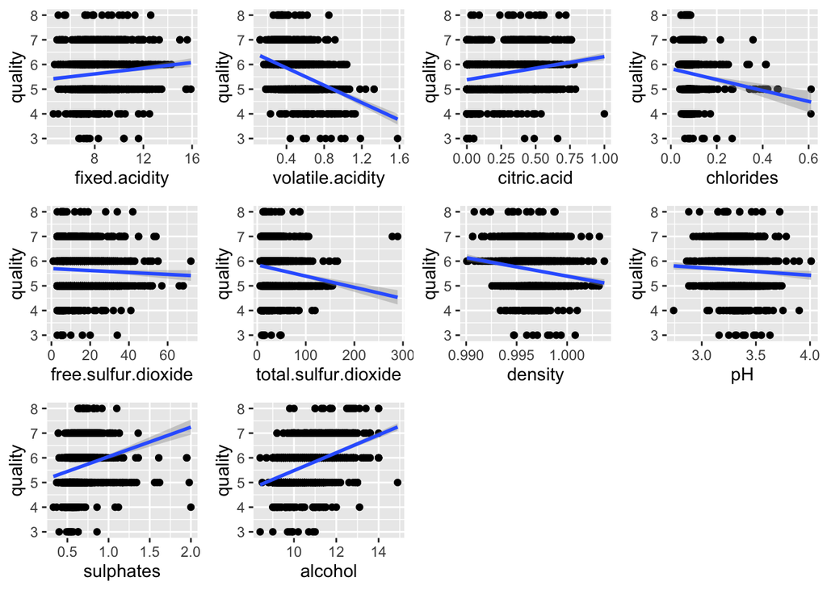

```r
#Loess curve relatinoship
#for (i in 1:11){
 # scatter.smooth(x=red[,i], y=red$quality, xlab= colnames(red[,i]))}


ggarrange(red %>%ggplot(aes(fixed.acidity,quality))+ geom_point()+ geom_smooth(method = "lm"),
red %>%ggplot(aes(volatile.acidity,quality))+ geom_point()+ geom_smooth(method = "lm"),
red %>%ggplot(aes(citric.acid,quality))+ geom_point()+ geom_smooth(method = "lm"),
red %>%ggplot(aes(chlorides,quality))+ geom_point()+ geom_smooth(method = "lm"),
red %>%ggplot(aes(free.sulfur.dioxide,quality))+ geom_point()+ geom_smooth(method = "lm"),
red %>%ggplot(aes(total.sulfur.dioxide,quality))+ geom_point()+ geom_smooth(method = "lm"),
red %>%ggplot(aes(density,quality))+ geom_point()+ geom_smooth(method = "lm"),
red %>%ggplot(aes(pH,quality))+ geom_point()+ geom_smooth(method = "lm"),
red %>%ggplot(aes(sulphates,quality))+ geom_point()+ geom_smooth(method = "lm"),
red %>%ggplot(aes(alcohol,quality))+ geom_point()+ geom_smooth(method = "lm"))
```

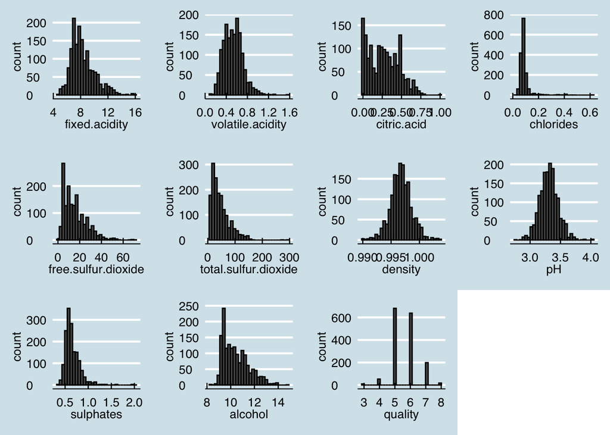

```r
ggarrange(red %>%ggplot(aes(fixed.acidity))+ geom_histogram(colour='black')+theme_economist(),
red %>%ggplot(aes(volatile.acidity))+ geom_histogram(colour='black')+theme_economist(),
red %>%ggplot(aes(citric.acid))+ geom_histogram(colour='black')+theme_economist(),
red %>%ggplot(aes(chlorides))+ geom_histogram(colour='black')+theme_economist(),
red %>%ggplot(aes(free.sulfur.dioxide))+ geom_histogram(colour='black')+theme_economist(),
red %>%ggplot(aes(total.sulfur.dioxide))+geom_histogram(colour='black')+theme_economist(),
red %>%ggplot(aes(density))+ geom_histogram(colour='black')+theme_economist(),
red %>%ggplot(aes(pH))+ geom_histogram(colour='black')+theme_economist(),
red %>%ggplot(aes(sulphates))+ geom_histogram(colour='black')+theme_economist(),
red %>%ggplot(aes(alcohol))+ geom_histogram(colour='black')+theme_economist(),
red %>%ggplot(aes(quality))+ geom_histogram(colour='black')+theme_economist())
```

```r
#print("Interesting to look at 2,3,5,6,7, 8,10,11. Columns 8 and 10 look like relationship with quality may note be linear")
```

White wine relationship between chemical composition and quality, and distribution of the chemical composition for the wines.

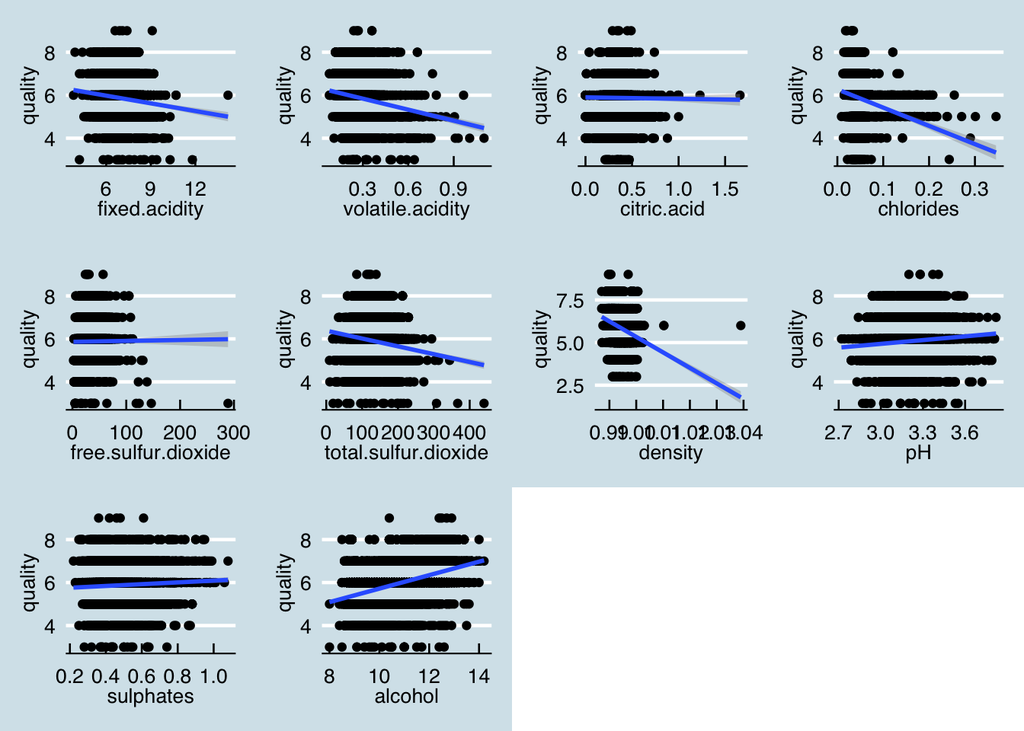

```r
#can see loess as well
#for (i in 1:11){
 # scatter.smooth(x=white[,i], y=white$quality, xlab= colnames(white[,i]))
#}

#print("Interesting to look at 1,2,3,5,6,7, 8,10,11 as relation")



ggarrange(white %>%ggplot(aes(fixed.acidity,quality))+ geom_point()+ geom_smooth(method = "lm")+theme_economist(),
white %>%ggplot(aes(volatile.acidity,quality))+ geom_point()+ geom_smooth(method = "lm")+theme_economist(),
white %>%ggplot(aes(citric.acid,quality))+ geom_point()+ geom_smooth(method = "lm")+theme_economist(),
white %>%ggplot(aes(chlorides,quality))+ geom_point()+ geom_smooth(method = "lm")+theme_economist(),
white %>%ggplot(aes(free.sulfur.dioxide,quality))+ geom_point()+ geom_smooth(method = "lm")+theme_economist(),
white %>%ggplot(aes(total.sulfur.dioxide,quality))+ geom_point()+ geom_smooth(method = "lm")+theme_economist(),
white %>%ggplot(aes(density,quality))+ geom_point()+ geom_smooth(method = "lm")+theme_economist(),
white %>%ggplot(aes(pH,quality))+ geom_point()+ geom_smooth(method = "lm")+theme_economist(),
white %>%ggplot(aes(sulphates,quality))+ geom_point()+ geom_smooth(method = "lm")+theme_economist(),
white %>%ggplot(aes(alcohol,quality))+ geom_point()+ geom_smooth(method = "lm")+theme_economist())
```

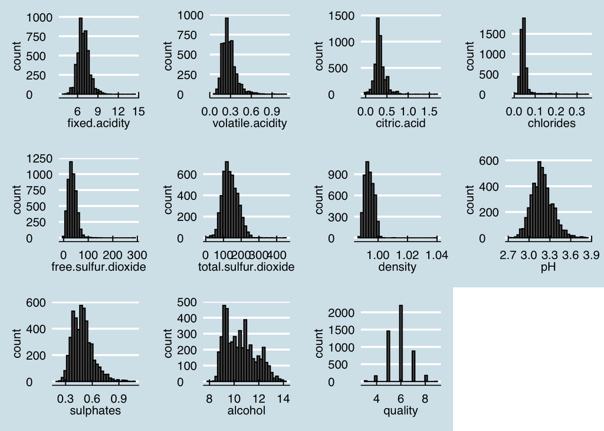

```r
ggarrange(white %>%ggplot(aes(fixed.acidity))+ geom_histogram(colour='black')+theme_economist(),
white %>%ggplot(aes(volatile.acidity))+ geom_histogram(colour='black')+theme_economist(),
white %>%ggplot(aes(citric.acid))+ geom_histogram(colour='black')+theme_economist(),
white %>%ggplot(aes(chlorides))+ geom_histogram(colour='black')+theme_economist(),
white %>%ggplot(aes(free.sulfur.dioxide))+ geom_histogram(colour='black')+theme_economist(),
white %>%ggplot(aes(total.sulfur.dioxide))+geom_histogram(colour='black')+theme_economist(),
white %>%ggplot(aes(density))+ geom_histogram(colour='black')+theme_economist(),
white %>%ggplot(aes(pH))+ geom_histogram(colour='black')+theme_economist(),
white %>%ggplot(aes(sulphates))+ geom_histogram(colour='black')+theme_economist(),
white %>%ggplot(aes(alcohol))+ geom_histogram(colour='black')+theme_economist(),
white %>%ggplot(aes(quality))+ geom_histogram(colour='black')+theme_economist())
```

We assume following characteristics about our data and model when we use a linear regression to model quality. •Firstly, that the average of Y(quality) is a linear function of X(chemical composition). We can already see from the plots above that the relationship is not linear for all cases and has quadratic and other relationship indicating linear regression is probably only interesting as an initial model • The variability of Y(quality) about the mean value is equal for all x values, again chemical composition. • The distribution of Y(quality) about its mean(average quality) is normally distributed this was checked via histograms or qq plots, again- this did not hold true for the predictors. • All responses are independent, which for factors like density, is not true as alcohol % and sugar levels affect density.

```r
qualities<-colnames(white)


#white with all covariates
linearWhite<-lm(quality~ fixed.acidity+volatile.acidity+ citric.acid+ residual.sugar+ chlorides+ free.sulfur.dioxide + total.sulfur.dioxide + pH +sulphates + alcohol, data= white)
summary(linearWhite)
```

```
##
## Call:
## lm(formula = quality ~ fixed.acidity + volatile.acidity + citric.acid +
##     residual.sugar + chlorides + free.sulfur.dioxide + total.sulfur.dioxide +
##     pH + sulphates + alcohol, data = white)
##
## Residuals:
##     Min      1Q  Median      3Q     Max
## -3.9098 -0.4957 -0.0330  0.4666  3.1785
##
## Coefficients:
##                        Estimate Std. Error t value Pr(>|t|)
## (Intercept)           2.0636371  0.3482321   5.926 3.32e-09 ***
## fixed.acidity        -0.0503197  0.0149092  -3.375 0.000744 ***
## volatile.acidity     -1.9583442  0.1138553 -17.200  < 2e-16 ***
## citric.acid          -0.0289483  0.0961455  -0.301 0.763360
## residual.sugar        0.0256438  0.0025518  10.049  < 2e-16 ***
## chlorides            -0.9525303  0.5425208  -1.756 0.079194 .
## free.sulfur.dioxide   0.0047672  0.0008391   5.682 1.41e-08 ***
## total.sulfur.dioxide -0.0008697  0.0003730  -2.331 0.019771 *
## pH                    0.1651688  0.0825418   2.001 0.045444 *
## sulphates             0.4193440  0.0973099   4.309 1.67e-05 ***
## alcohol               0.3626941  0.0112672  32.190  < 2e-16 ***
## ---
## Signif. codes:  0 '***' 0.001 '**' 0.01 '*' 0.05 '.' 0.1 ' ' 1
##
## Residual standard error: 0.756 on 4887 degrees of freedom
## Multiple R-squared:  0.2727, Adjusted R-squared:  0.2713
## F-statistic: 183.3 on 10 and 4887 DF,  p-value: < 2.2e-16
```

```r
#white removing covariates that are not significant
linearWhite2<-lm(quality~ fixed.acidity+volatile.acidity+ residual.sugar+  free.sulfur.dioxide  + pH +sulphates + alcohol, data= white)
summary(linearWhite2)
```

```
##
## Call:
## lm(formula = quality ~ fixed.acidity + volatile.acidity + residual.sugar +
##     free.sulfur.dioxide + pH + sulphates + alcohol, data = white)
##
## Residuals:
##     Min      1Q  Median      3Q     Max
## -3.8605 -0.4982 -0.0372  0.4599  3.2028
##
## Coefficients:
##                      Estimate Std. Error t value Pr(>|t|)
## (Intercept)          1.892072   0.337214   5.611 2.12e-08 ***
## fixed.acidity       -0.055632   0.014278  -3.896 9.90e-05 ***
## volatile.acidity    -2.034356   0.108888 -18.683  < 2e-16 ***
## residual.sugar       0.025225   0.002500  10.089  < 2e-16 ***
## free.sulfur.dioxide  0.003551   0.000681   5.215 1.92e-07 ***
## pH                   0.153290   0.081479   1.881     0.06 .
## sulphates            0.383213   0.096303   3.979 7.01e-05 ***
## alcohol              0.377600   0.010029  37.650  < 2e-16 ***
## ---
## Signif. codes:  0 '***' 0.001 '**' 0.01 '*' 0.05 '.' 0.1 ' ' 1
##
## Residual standard error: 0.7565 on 4890 degrees of freedom
## Multiple R-squared:  0.2714, Adjusted R-squared:  0.2703
## F-statistic: 260.2 on 7 and 4890 DF,  p-value: < 2.2e-16
```

```r
# checking significance of coefficient- adjusted r^2 is higher with all than with removing
linearRed<-lm(quality~ fixed.acidity+volatile.acidity+ citric.acid+ residual.sugar+ chlorides+ free.sulfur.dioxide + total.sulfur.dioxide + pH +sulphates + alcohol, data= red)
summary(linearRed)
```

```
##
## Call:
## lm(formula = quality ~ fixed.acidity + volatile.acidity + citric.acid +
##     residual.sugar + chlorides + free.sulfur.dioxide + total.sulfur.dioxide +
##     pH + sulphates + alcohol, data = red)
##
## Residuals:
##      Min       1Q   Median       3Q      Max
## -2.67204 -0.36527 -0.04523  0.45628  2.03894
##
## Coefficients:
##                        Estimate Std. Error t value Pr(>|t|)
## (Intercept)           4.4538341  0.6125783   7.271 5.59e-13 ***
## fixed.acidity         0.0081441  0.0160586   0.507  0.61212
## volatile.acidity     -1.0964449  0.1200866  -9.130  < 2e-16 ***
## citric.acid          -0.1836098  0.1471561  -1.248  0.21232
## residual.sugar        0.0089507  0.0120542   0.743  0.45787
## chlorides            -1.9067341  0.4173928  -4.568 5.30e-06 ***
## free.sulfur.dioxide   0.0045147  0.0021631   2.087  0.03704 *
## total.sulfur.dioxide -0.0033120  0.0007264  -4.560 5.52e-06 ***
## pH                   -0.5042762  0.1571117  -3.210  0.00136 **
## sulphates             0.8928974  0.1107548   8.062 1.46e-15 ***
## alcohol               0.2927427  0.0173394  16.883  < 2e-16 ***
## ---
## Signif. codes:  0 '***' 0.001 '**' 0.01 '*' 0.05 '.' 0.1 ' ' 1
##
## Residual standard error: 0.6479 on 1588 degrees of freedom
## Multiple R-squared:  0.3603, Adjusted R-squared:  0.3562
## F-statistic: 89.43 on 10 and 1588 DF,  p-value: < 2.2e-16
```

```r
# remove not signitficant qualities adjusted r squared is lower
linearRed2<-lm(quality~ fixed.acidity+volatile.acidity+  residual.sugar+ chlorides+ free.sulfur.dioxide+  pH +sulphates + alcohol, data= red)
summary(linearRed2)
```

```
##
## Call:
## lm(formula = quality ~ fixed.acidity + volatile.acidity + residual.sugar +
##     chlorides + free.sulfur.dioxide + pH + sulphates + alcohol,
##     data = red)
##
## Residuals:
##      Min       1Q   Median       3Q      Max
## -2.58969 -0.35629 -0.05642  0.47278  1.95772
##
## Coefficients:
##                       Estimate Std. Error t value Pr(>|t|)
## (Intercept)          3.738e+00  5.974e-01   6.258 5.01e-10 ***
## fixed.acidity        8.031e-03  1.335e-02   0.602   0.5475
## volatile.acidity    -1.068e+00  1.014e-01 -10.533  < 2e-16 ***
## residual.sugar       3.066e-05  1.202e-02   0.003   0.9980
## chlorides           -1.907e+00  4.046e-01  -4.712 2.67e-06 ***
## free.sulfur.dioxide -2.072e-03  1.636e-03  -1.266   0.2057
## pH                  -3.388e-01  1.551e-01  -2.184   0.0291 *
## sulphates            8.524e-01  1.114e-01   7.655 3.32e-14 ***
## alcohol              3.027e-01  1.680e-02  18.014  < 2e-16 ***
## ---
## Signif. codes:  0 '***' 0.001 '**' 0.01 '*' 0.05 '.' 0.1 ' ' 1
##
## Residual standard error: 0.6531 on 1590 degrees of freedom
## Multiple R-squared:  0.3493, Adjusted R-squared:  0.346
## F-statistic: 106.7 on 8 and 1590 DF,  p-value: < 2.2e-16
```

Model selection:density of the wine is a product of sugar and alcohol concentrations, thus acting as a confounder due to correlation, and thus removed it from our model.

It is worth reiterating that we can only use linear regression when all the LINE requirements, which were previously outlines hold true for the data set. We saw from the original plots where we were comparing the relationship between wine features and quality is not linear. You can also remove the hash tag in the R-markdown to see this more clearly with LOESS curves to show the patterns.

For the red wines, fixed acidity, citric acid levels and residual sugar levels were not associated with wine quality. For red wines, the chemical compositions were able to explain 35% of variability before and after removing these chemical features. To see whether qualities are positively or negatively correlated with wine quality, you can look at the estimate, if it is positive, then it is positively correlated with quality.

# Ordinal Regressions

### Running the Regressions

We ran a series of ordinal logistic regressions with the package vglm. We ran four ordinal logistic regressions to examine differences between the using 3 outcome categories for quality, and the full 7 outcome categories. We decided to use the coarsened categories (3) because we had more data per level and could thus categorize the wines better. We used an AIC comparison for the models, and selected the reduced model omod2 because it had a slightly lower AIC than the full model. Anova analysis confirmed that the extra variables in the full model do not contribute significant information, so this reinforced our decision to use the reduced model. We performed the same set of analyses on white wines, as well.

```r
omod1 = vglm(qualcat ~ fixed.acidity+volatile.acidity+ citric.acid+ residual.sugar+ chlorides+ free.sulfur.dioxide + total.sulfur.dioxide+ pH +sulphates + alcohol,
             cumulative(parallel=TRUE, reverse=FALSE), data=red)
summary(omod1)
```

```
##
## Call:
## vglm(formula = qualcat ~ fixed.acidity + volatile.acidity + citric.acid +
##     residual.sugar + chlorides + free.sulfur.dioxide + total.sulfur.dioxide +
##     pH + sulphates + alcohol, family = cumulative(parallel = TRUE,
##     reverse = FALSE), data = red)
##
## Pearson residuals:
##                        Min      1Q  Median       3Q    Max
## logitlink(P[Y<=1])  -1.221 -0.2282 -0.1344 -0.06632 22.999
## logitlink(P[Y<=2]) -10.908  0.1078  0.1831  0.33562  5.201
##
## Coefficients:
##                       Estimate Std. Error z value Pr(>|z|)
## (Intercept):1        -2.432168   2.716550  -0.895 0.370619
## (Intercept):2         4.223282   2.721945   1.552 0.120766
## fixed.acidity        -0.018428   0.067758  -0.272 0.785645
## volatile.acidity      3.954515   0.541950   7.297 2.95e-13 ***
## citric.acid          -0.028983   0.658821  -0.044 0.964910
## residual.sugar       -0.053930   0.053077  -1.016 0.309593
## chlorides             6.848748   1.933108   3.543 0.000396 ***
## free.sulfur.dioxide  -0.004968   0.009585  -0.518 0.604270
## total.sulfur.dioxide  0.004046   0.003234   1.251 0.210903
## pH                    1.953862   0.700681   2.789 0.005295 **
## sulphates            -2.563013   0.456232  -5.618 1.93e-08 ***
## alcohol              -0.854487   0.079123 -10.800  < 2e-16 ***
## ---
## Signif. codes:  0 '***' 0.001 '**' 0.01 '*' 0.05 '.' 0.1 ' ' 1
##
## Names of linear predictors: logitlink(P[Y<=1]), logitlink(P[Y<=2])
##
## Residual deviance: 1374.654 on 3186 degrees of freedom
##
## Log-likelihood: -687.3271 on 3186 degrees of freedom
##
## Number of Fisher scoring iterations: 6
##
## No Hauck-Donner effect found in any of the estimates
##
##
## Exponentiated coefficients:
##        fixed.acidity     volatile.acidity          citric.acid
##           0.98174063          52.17039481           0.97143265
##       residual.sugar            chlorides  free.sulfur.dioxide
##           0.94749858         942.69953374           0.99504459
## total.sulfur.dioxide                   pH            sulphates
##           1.00405456           7.05588385           0.07707217
##              alcohol
##           0.42550144
```

```r
omod2 = vglm(qualcat ~ volatile.acidity+chlorides+sulphates + alcohol + pH,
             cumulative(parallel=TRUE, reverse=FALSE), data=red)
summary(omod2)
```

```
##
## Call:
## vglm(formula = qualcat ~ volatile.acidity + chlorides + sulphates +
##     alcohol + pH, family = cumulative(parallel = TRUE, reverse = FALSE),
##     data = red)
##
## Pearson residuals:
##                       Min      1Q  Median       3Q    Max
## logitlink(P[Y<=1])  -1.09 -0.2233 -0.1368 -0.06798 20.045
## logitlink(P[Y<=2]) -11.01  0.1130  0.1870  0.33477  4.683
##
## Coefficients:
##                  Estimate Std. Error z value Pr(>|z|)
## (Intercept):1     -3.0014     1.7673  -1.698 0.089460 .
## (Intercept):2      3.6181     1.7644   2.051 0.040307 *
## volatile.acidity   4.0158     0.4682   8.577  < 2e-16 ***
## chlorides          6.5874     1.8596   3.542 0.000397 ***
## sulphates         -2.4781     0.4530  -5.471 4.48e-08 ***
## alcohol           -0.8712     0.0758 -11.493  < 2e-16 ***
## pH                 2.1071     0.5200   4.052 5.07e-05 ***
## ---
## Signif. codes:  0 '***' 0.001 '**' 0.01 '*' 0.05 '.' 0.1 ' ' 1
##
## Names of linear predictors: logitlink(P[Y<=1]), logitlink(P[Y<=2])
##
## Residual deviance: 1377.603 on 3191 degrees of freedom
##
## Log-likelihood: -688.8017 on 3191 degrees of freedom
##
## Number of Fisher scoring iterations: 6
##
## No Hauck-Donner effect found in any of the estimates
##
##
## Exponentiated coefficients:
## volatile.acidity        chlorides        sulphates          alcohol
##      55.47009754     725.91476910       0.08390607       0.41846778
##               pH
##       8.22426573
```

```r
omod3 = vglm(quality ~ fixed.acidity+volatile.acidity+ citric.acid+ residual.sugar+ chlorides+ free.sulfur.dioxide + total.sulfur.dioxide+ density + pH +sulphates + alcohol,
             cumulative(parallel=TRUE, reverse=FALSE), data=red)
summary(omod3)
```

```
##
## Call:
## vglm(formula = quality ~ fixed.acidity + volatile.acidity + citric.acid +
##     residual.sugar + chlorides + free.sulfur.dioxide + total.sulfur.dioxide +
##     density + pH + sulphates + alcohol, family = cumulative(parallel = TRUE,
##     reverse = FALSE), data = red)
##
## Pearson residuals:
##                       Min       1Q   Median       3Q     Max
## logitlink(P[Y<=1]) -2.688 -0.07004 -0.04110 -0.02122 22.0074
## logitlink(P[Y<=2]) -1.170 -0.23334 -0.12871 -0.05832 24.5678
## logitlink(P[Y<=3]) -3.790 -0.64871 -0.15733  0.65334 22.4926
## logitlink(P[Y<=4]) -8.447  0.08999  0.17525  0.34652  2.1109
## logitlink(P[Y<=5]) -9.860  0.02728  0.04473  0.09034  0.5235
##
## Coefficients:
##                        Estimate Std. Error z value Pr(>|z|)
## (Intercept):1        -75.712573  65.247486  -1.160 0.245890
## (Intercept):2        -73.795169  65.249108      NA       NA
## (Intercept):3        -70.081700  65.255092  -1.074 0.282838
## (Intercept):4        -67.223439  65.248954  -1.030 0.302888
## (Intercept):5        -64.214387  65.244738  -0.984 0.325013
## fixed.acidity         -0.128180   0.079663  -1.609 0.107610
## volatile.acidity       3.395885   0.391299   8.678  < 2e-16 ***
## citric.acid            0.802191   0.459150   1.747 0.080616 .
## residual.sugar        -0.087751   0.046134  -1.902 0.057156 .
## chlorides              5.142899   1.325273   3.881 0.000104 ***
## free.sulfur.dioxide   -0.013682   0.006758  -2.025 0.042918 *
## total.sulfur.dioxide   0.011124   0.002321   4.792 1.65e-06 ***
## density               76.319316  66.607607      NA       NA
## pH                     0.848526   0.591638   1.434 0.151516
## sulphates             -2.901689   0.356057  -8.150 3.65e-16 ***
## alcohol               -0.830966   0.083886  -9.906  < 2e-16 ***
## ---
## Signif. codes:  0 '***' 0.001 '**' 0.01 '*' 0.05 '.' 0.1 ' ' 1
##
## Number of linear predictors:  5
##
## Names of linear predictors: logitlink(P[Y<=1]), logitlink(P[Y<=2]),
## logitlink(P[Y<=3]), logitlink(P[Y<=4]), logitlink(P[Y<=5])
##
## Residual deviance: 3074.767 on 7979 degrees of freedom
##
## Log-likelihood: -1537.383 on 7979 degrees of freedom
##
## Number of Fisher scoring iterations: 6
##
## Warning: Hauck-Donner effect detected in the following estimate(s):
## '(Intercept):2', 'density'
##
##
## Exponentiated coefficients:
##        fixed.acidity     volatile.acidity          citric.acid
##         8.796950e-01         2.984104e+01         2.230423e+00
##       residual.sugar            chlorides  free.sulfur.dioxide
##         9.159887e-01         1.712115e+02         9.864115e-01
## total.sulfur.dioxide              density                   pH
##         1.011186e+00         1.396554e+33         2.336200e+00
##            sulphates              alcohol
##         5.493036e-02         4.356282e-01
```

```r
omod4 = vglm(quality ~ volatile.acidity+chlorides+sulphates + alcohol+ total.sulfur.dioxide,
             cumulative(parallel=TRUE, reverse=FALSE), data=red)
summary(omod4)
```

```
##
## Call:
## vglm(formula = quality ~ volatile.acidity + chlorides + sulphates +
##     alcohol + total.sulfur.dioxide, family = cumulative(parallel = TRUE,
##     reverse = FALSE), data = red)
##
## Pearson residuals:
##                        Min       1Q   Median       3Q     Max
## logitlink(P[Y<=1])  -2.402 -0.06861 -0.04142 -0.02193 20.2806
## logitlink(P[Y<=2])  -1.219 -0.22894 -0.12966 -0.06026 21.8577
## logitlink(P[Y<=3])  -3.861 -0.64162 -0.16243  0.66735 11.9166
## logitlink(P[Y<=4])  -8.109  0.09291  0.17514  0.35165  2.2665
## logitlink(P[Y<=5]) -10.159  0.02866  0.04594  0.09156  0.5363
##
## Coefficients:
##                       Estimate Std. Error z value Pr(>|z|)
## (Intercept):1         2.193002   0.713916   3.072  0.00213 **
## (Intercept):2         4.107938   0.653270   6.288 3.21e-10 ***
## (Intercept):3         7.802636   0.651640  11.974  < 2e-16 ***
## (Intercept):4        10.621349   0.687171  15.457  < 2e-16 ***
## (Intercept):5        13.623421   0.745978  18.262  < 2e-16 ***
## volatile.acidity      3.404273   0.311726  10.921  < 2e-16 ***
## chlorides             4.933553   1.224472   4.029 5.60e-05 ***
## sulphates            -2.825553   0.340867  -8.289  < 2e-16 ***
## alcohol              -0.848475   0.054757 -15.495  < 2e-16 ***
## total.sulfur.dioxide  0.008172   0.001600   5.107 3.26e-07 ***
## ---
## Signif. codes:  0 '***' 0.001 '**' 0.01 '*' 0.05 '.' 0.1 ' ' 1
##
## Number of linear predictors:  5
##
## Names of linear predictors: logitlink(P[Y<=1]), logitlink(P[Y<=2]),
## logitlink(P[Y<=3]), logitlink(P[Y<=4]), logitlink(P[Y<=5])
##
## Residual deviance: 3097.486 on 7985 degrees of freedom
##
## Log-likelihood: -1548.743 on 7985 degrees of freedom
##
## Number of Fisher scoring iterations: 6
##
## No Hauck-Donner effect found in any of the estimates
##
##
## Exponentiated coefficients:
##     volatile.acidity            chlorides            sulphates
##          30.09242368         138.87199661           0.05927585
##              alcohol total.sulfur.dioxide
##           0.42806734           1.00820570
```

```r
#Comparing AICs for ordinal logistic regression of qualcat (3 categories) vs quality (5 in the case of red)
```

We selected models based on lower AICs because the Akaike Information Criterion is a relative measure of model performance that takes into account both parsimony and goodness of fit. Penalizing the number of parameters included rewards parsimony, and thus helps reduce overfitting. Therefore, the AIC is a relative, useful measure of model performance, with lower values indicating the better model.

```r
AICvlm(omod1, corrected = FALSE)
```

```
## [1] 1398.654
```

```r
AICvlm(omod2, corrected = FALSE)
```

```
## [1] 1391.603
```

```r
AICvlm(omod3, corrected = FALSE)
```

```
## [1] 3106.767
```

```r
AICvlm(omod4, corrected = FALSE)
```

```
## [1] 3117.486
```

```r
anova.vglm(omod1, omod2, type = "I")
```

```
## Analysis of Deviance Table
##
## Model 1: qualcat ~ fixed.acidity + volatile.acidity + citric.acid + residual.sugar +
##     chlorides + free.sulfur.dioxide + total.sulfur.dioxide +
##     pH + sulphates + alcohol
## Model 2: qualcat ~ volatile.acidity + chlorides + sulphates + alcohol +
##     pH
##   Resid. Df Resid. Dev Df Deviance Pr(>Chi)
## 1      3186     1374.7
## 2      3191     1377.6 -5  -2.9492   0.7078
```

```r
waldtest(omod1, omod2)
```

```
## Wald test
##
## Model 1: qualcat ~ fixed.acidity + volatile.acidity + citric.acid + residual.sugar +
##     chlorides + free.sulfur.dioxide + total.sulfur.dioxide +
##     pH + sulphates + alcohol
## Model 2: qualcat ~ volatile.acidity + chlorides + sulphates + alcohol +
##     pH
##   Res.Df Df Chisq Pr(>Chisq)
## 1   3186
## 2   3191 -5 2.963     0.7057
```

```r
#White wines

omodww1 = vglm(qualcat ~ fixed.acidity+volatile.acidity+ citric.acid+ residual.sugar+ chlorides+ free.sulfur.dioxide + total.sulfur.dioxide + pH +sulphates + alcohol,
             cumulative(parallel=TRUE, reverse=FALSE), data=white)
summary(omodww1)
```

```
##
## Call:
## vglm(formula = qualcat ~ fixed.acidity + volatile.acidity + citric.acid +
##     residual.sugar + chlorides + free.sulfur.dioxide + total.sulfur.dioxide +
##     pH + sulphates + alcohol, family = cumulative(parallel = TRUE,
##     reverse = FALSE), data = white)
##
## Pearson residuals:
##                       Min      1Q  Median       3Q    Max
## logitlink(P[Y<=1]) -1.214 -0.2129 -0.1370 -0.08764 39.544
## logitlink(P[Y<=2]) -6.643  0.1265  0.3281  0.51386  2.275
##
## Coefficients:
##                       Estimate Std. Error z value Pr(>|z|)
## (Intercept):1         6.067692   1.141621   5.315 1.07e-07 ***
## (Intercept):2        11.511740   1.156867   9.951  < 2e-16 ***
## fixed.acidity         0.111181   0.049398   2.251  0.02440 *
## volatile.acidity      4.567039   0.380122  12.015  < 2e-16 ***
## citric.acid           0.236439   0.321265   0.736  0.46175
## residual.sugar       -0.062336   0.008509  -7.326 2.37e-13 ***
## chlorides             5.162464   1.837959   2.809  0.00497 **
## free.sulfur.dioxide  -0.014755   0.002728  -5.410 6.32e-08 ***
## total.sulfur.dioxide  0.001623   0.001235   1.314  0.18876
## pH                   -0.522543   0.265329  -1.969  0.04891 *
## sulphates            -1.181882   0.300531  -3.933 8.40e-05 ***
## alcohol              -0.886226   0.038841 -22.817  < 2e-16 ***
## ---
## Signif. codes:  0 '***' 0.001 '**' 0.01 '*' 0.05 '.' 0.1 ' ' 1
##
## Names of linear predictors: logitlink(P[Y<=1]), logitlink(P[Y<=2])
##
## Residual deviance: 5604.864 on 9784 degrees of freedom
##
## Log-likelihood: -2802.432 on 9784 degrees of freedom
##
## Number of Fisher scoring iterations: 6
##
## Warning: Hauck-Donner effect detected in the following estimate(s):
## '(Intercept):2'
##
##
## Exponentiated coefficients:
##        fixed.acidity     volatile.acidity          citric.acid
##            1.1175973           96.2587123            1.2667304
##       residual.sugar            chlorides  free.sulfur.dioxide
##            0.9395669          174.5941267            0.9853535
## total.sulfur.dioxide                   pH            sulphates
##            1.0016243            0.5930105            0.3067011
##              alcohol
##            0.4122083
```

```r
omodww2 = vglm(qualcat ~ volatile.acidity+chlorides+sulphates + alcohol + pH,
             cumulative(parallel=TRUE, reverse=FALSE), data=white)
summary(omodww2)
```

```
##
## Call:
## vglm(formula = qualcat ~ volatile.acidity + chlorides + sulphates +
##     alcohol + pH, family = cumulative(parallel = TRUE, reverse = FALSE),
##     data = white)
##
## Pearson residuals:
##                       Min      1Q  Median       3Q    Max
## logitlink(P[Y<=1]) -1.198 -0.2291 -0.1424 -0.09208 17.003
## logitlink(P[Y<=2]) -5.646  0.1323  0.3257  0.52767  2.059
##
## Coefficients:
##                  Estimate Std. Error z value Pr(>|z|)
## (Intercept):1      4.8808     0.8016   6.089 1.14e-09 ***
## (Intercept):2     10.2057     0.8169  12.493  < 2e-16 ***
## volatile.acidity   4.3040     0.3580  12.021  < 2e-16 ***
## chlorides          6.0858     1.7797   3.419 0.000627 ***
## sulphates         -1.0653     0.2941  -3.623 0.000291 ***
## alcohol           -0.7461     0.0327 -22.818  < 2e-16 ***
## pH                -0.5485     0.2295  -2.390 0.016829 *
## ---
## Signif. codes:  0 '***' 0.001 '**' 0.01 '*' 0.05 '.' 0.1 ' ' 1
##
## Names of linear predictors: logitlink(P[Y<=1]), logitlink(P[Y<=2])
##
## Residual deviance: 5721.532 on 9789 degrees of freedom
##
## Log-likelihood: -2860.766 on 9789 degrees of freedom
##
## Number of Fisher scoring iterations: 5
##
## Warning: Hauck-Donner effect detected in the following estimate(s):
## '(Intercept):2'
##
##
## Exponentiated coefficients:
## volatile.acidity        chlorides        sulphates          alcohol
##       73.9918418      439.5891546        0.3446156        0.4742169
##               pH
##        0.5778121
```

```r
omodww3 = vglm(quality ~ fixed.acidity+volatile.acidity+ citric.acid+ residual.sugar+ chlorides+ free.sulfur.dioxide + total.sulfur.dioxide+ density + pH +sulphates + alcohol,
             cumulative(parallel=TRUE, reverse=FALSE), data=white)
summary(omodww3)
```

```
##
## Call:
## vglm(formula = quality ~ fixed.acidity + volatile.acidity + citric.acid +
##     residual.sugar + chlorides + free.sulfur.dioxide + total.sulfur.dioxide +
##     density + pH + sulphates + alcohol, family = cumulative(parallel = TRUE,
##     reverse = FALSE), data = white)
##
## Pearson residuals:
##                        Min       1Q   Median       3Q      Max
## logitlink(P[Y<=1])  -2.132 -0.05182 -0.03339 -0.02058 107.1121
## logitlink(P[Y<=2])  -2.739 -0.22120 -0.10859 -0.06220  28.9623
## logitlink(P[Y<=3]) -69.716 -0.62215 -0.26676  0.70075   9.2199
## logitlink(P[Y<=4])  -7.563  0.10190  0.24239  0.51056   4.1116
## logitlink(P[Y<=5]) -17.185  0.06197  0.09840  0.18520   1.0167
## logitlink(P[Y<=6]) -44.537  0.01232  0.01883  0.03110   0.3881
##
## Coefficients:
##                        Estimate Std. Error z value Pr(>|z|)
## (Intercept):1        -4.519e+02  5.661e+01  -7.981 1.45e-15 ***
## (Intercept):2        -4.495e+02  5.661e+01  -7.941 2.01e-15 ***
## (Intercept):3        -4.465e+02  5.660e+01  -7.888 3.08e-15 ***
## (Intercept):4        -4.439e+02  5.660e+01  -7.842 4.42e-15 ***
## (Intercept):5        -4.416e+02  5.660e+01  -7.803 6.05e-15 ***
## (Intercept):6        -4.380e+02  5.660e+01  -7.738 1.01e-14 ***
## fixed.acidity        -2.314e-01  5.765e-02  -4.015 5.96e-05 ***
## volatile.acidity      4.982e+00  3.030e-01  16.441  < 2e-16 ***
## citric.acid          -1.238e-01  2.457e-01  -0.504    0.614
## residual.sugar       -2.306e-01  2.172e-02 -10.619  < 2e-16 ***
## chlorides             6.079e-01  1.413e+00   0.430    0.667
## free.sulfur.dioxide  -1.193e-02  2.169e-03  -5.500 3.79e-08 ***
## total.sulfur.dioxide  9.073e-04  9.803e-04   0.926    0.355
## density               4.623e+02  5.738e+01   8.057 7.84e-16 ***
## pH                   -2.068e+00  2.844e-01  -7.273 3.51e-13 ***
## sulphates            -1.815e+00  2.589e-01  -7.013 2.34e-12 ***
## alcohol              -4.299e-01  7.175e-02  -5.992 2.08e-09 ***
## ---
## Signif. codes:  0 '***' 0.001 '**' 0.01 '*' 0.05 '.' 0.1 ' ' 1
##
## Number of linear predictors:  6
##
## Names of linear predictors: logitlink(P[Y<=1]), logitlink(P[Y<=2]),
## logitlink(P[Y<=3]), logitlink(P[Y<=4]), logitlink(P[Y<=5]), logitlink(P[Y<=6])
##
## Residual deviance: 10900.89 on 29371 degrees of freedom
##
## Log-likelihood: -5450.445 on 29371 degrees of freedom
##
## Number of Fisher scoring iterations: 7
##
## Warning: Hauck-Donner effect detected in the following estimate(s):
## '(Intercept):2', '(Intercept):3', 'density'
##
##
## Exponentiated coefficients:
##        fixed.acidity     volatile.acidity          citric.acid
##         7.934084e-01         1.457560e+02         8.835384e-01
##       residual.sugar            chlorides  free.sulfur.dioxide
##         7.940181e-01         1.836620e+00         9.881404e-01
## total.sulfur.dioxide              density                   pH
##         1.000908e+00        6.049187e+200         1.263949e-01
##            sulphates              alcohol
##         1.627998e-01         6.505714e-01
```

```r
omodww4 = vglm(quality ~ volatile.acidity+chlorides+sulphates + alcohol+ total.sulfur.dioxide,
             cumulative(parallel=TRUE, reverse=FALSE), data=white)
summary(omodww4)
```

```
##
## Call:
## vglm(formula = quality ~ volatile.acidity + chlorides + sulphates +
##     alcohol + total.sulfur.dioxide, family = cumulative(parallel = TRUE,
##     reverse = FALSE), data = white)
##
## Pearson residuals:
##                        Min       1Q   Median       3Q     Max
## logitlink(P[Y<=1])  -1.444 -0.05556 -0.03584 -0.02331 37.9514
## logitlink(P[Y<=2])  -1.086 -0.22918 -0.11363 -0.06886 18.5485
## logitlink(P[Y<=3])  -3.422 -0.64360 -0.27392  0.76557  5.0015
## logitlink(P[Y<=4])  -6.525  0.10962  0.25316  0.52750  2.2916
## logitlink(P[Y<=5]) -11.897  0.06603  0.10392  0.18853  0.8796
## logitlink(P[Y<=6]) -43.782  0.01340  0.02038  0.03184  0.2815
##
## Coefficients:
##                        Estimate Std. Error z value Pr(>|z|)
## (Intercept):1         2.0698936  0.4327993   4.783 1.73e-06 ***
## (Intercept):2         4.3778567  0.3773347  11.602  < 2e-16 ***
## (Intercept):3         7.3281187  0.3761138  19.484  < 2e-16 ***
## (Intercept):4         9.8317579  0.3903711  25.186  < 2e-16 ***
## (Intercept):5        12.0277918  0.4037394  29.791  < 2e-16 ***
## (Intercept):6        15.6899926  0.5976183  26.254  < 2e-16 ***
## volatile.acidity      5.1722958  0.2883194  17.939  < 2e-16 ***
## chlorides             4.0895169  1.3694861   2.986 0.002825 **
## sulphates            -1.0467220  0.2413858  -4.336 1.45e-05 ***
## alcohol              -0.8524945  0.0290697 -29.326  < 2e-16 ***
## total.sulfur.dioxide -0.0026060  0.0007354  -3.544 0.000395 ***
## ---
## Signif. codes:  0 '***' 0.001 '**' 0.01 '*' 0.05 '.' 0.1 ' ' 1
##
## Number of linear predictors:  6
##
## Names of linear predictors: logitlink(P[Y<=1]), logitlink(P[Y<=2]),
## logitlink(P[Y<=3]), logitlink(P[Y<=4]), logitlink(P[Y<=5]), logitlink(P[Y<=6])
##
## Residual deviance: 11148.63 on 29377 degrees of freedom
##
## Log-likelihood: -5574.314 on 29377 degrees of freedom
##
## Number of Fisher scoring iterations: 5
##
## Warning: Hauck-Donner effect detected in the following estimate(s):
## '(Intercept):6'
##
##
## Exponentiated coefficients:
##     volatile.acidity            chlorides            sulphates
##          176.3191731           59.7110374            0.3510867
##              alcohol total.sulfur.dioxide
##            0.4263501            0.9973974
```

```r
omodww5 = vglm(qualcat ~ volatile.acidity+sulphates + alcohol+ total.sulfur.dioxide,
             cumulative(parallel=TRUE, reverse=FALSE), data=white)
summary(omodww5)
```

```
##
## Call:
## vglm(formula = qualcat ~ volatile.acidity + sulphates + alcohol +
##     total.sulfur.dioxide, family = cumulative(parallel = TRUE,
##     reverse = FALSE), data = white)
##
## Pearson residuals:
##                        Min      1Q  Median       3Q    Max
## logitlink(P[Y<=1]) -0.9485 -0.2280 -0.1467 -0.09442 15.730
## logitlink(P[Y<=2]) -5.4325  0.1333  0.3313  0.51771  2.033
##
## Coefficients:
##                        Estimate Std. Error z value Pr(>|z|)
## (Intercept):1         4.7883580  0.4306080  11.120  < 2e-16 ***
## (Intercept):2        10.0907796  0.4561158  22.123  < 2e-16 ***
## volatile.acidity      4.6575931  0.3600330  12.937  < 2e-16 ***
## sulphates            -1.0193315  0.2934886  -3.473 0.000514 ***
## alcohol              -0.8403388  0.0344021 -24.427  < 2e-16 ***
## total.sulfur.dioxide -0.0035495  0.0009449  -3.757 0.000172 ***
## ---
## Signif. codes:  0 '***' 0.001 '**' 0.01 '*' 0.05 '.' 0.1 ' ' 1
##
## Names of linear predictors: logitlink(P[Y<=1]), logitlink(P[Y<=2])
##
## Residual deviance: 5725.88 on 9790 degrees of freedom
##
## Log-likelihood: -2862.94 on 9790 degrees of freedom
##
## Number of Fisher scoring iterations: 5
##
## Warning: Hauck-Donner effect detected in the following estimate(s):
## '(Intercept):2'
##
##
## Exponentiated coefficients:
##     volatile.acidity            sulphates              alcohol
##          105.3821353            0.3608361            0.4315643
## total.sulfur.dioxide
##            0.9964568
```

```r
#Comparing AICs for ordinal logistic regression of qualcat (3 categories) vs quality (7 in the case of white)
AICvlm(omodww1, corrected = FALSE)
```

```
## [1] 5628.864
```

```r
AICvlm(omodww2, corrected = FALSE)
```

```
## [1] 5735.532
```

```r
AICvlm(omodww3, corrected = FALSE)
```

```
## [1] 10934.89
```

```r
AICvlm(omodww4, corrected = FALSE)
```

```
## [1] 11170.63
```

```r
AICvlm(omodww5, corrected = FALSE)
```

```
## [1] 5737.879
```

### Checking Assumptions

```r
red <- red %>% mutate(bin3 = ifelse(qualcat == 3, 1, 0))
red <- red %>% mutate(bin23 = ifelse(qualcat == 1, 0, 1))

lmod1 <- glm(bin3 ~ volatile.acidity+chlorides+sulphates + alcohol + pH, family = binomial(), data = red)
lmod2 <- glm(bin23 ~ volatile.acidity+chlorides+sulphates + alcohol + pH, family = binomial(), data = red)

coef(lmod1)
```

```
##      (Intercept) volatile.acidity        chlorides        sulphates
##        -6.763130        -3.528593        -7.601353         2.817664
##          alcohol               pH
##         1.018734        -1.766181
```

```r
coef(lmod2)
```

```
##      (Intercept) volatile.acidity        chlorides        sulphates
##       11.9512511       -4.2579548       -7.0684312        2.0365351
##          alcohol               pH
##        0.1783705       -2.5735841
```

```r
confint(lmod1)
```

```
##                       2.5 %     97.5 %
## (Intercept)      -10.896647 -2.6493572
## volatile.acidity  -4.775638 -2.3273567
## chlorides        -14.307589 -2.3641517
## sulphates          1.854735  3.8146315
## alcohol            0.853866  1.1908990
## pH                -2.965456 -0.5875281
```

```r
confint(lmod2)
```

```
##                        2.5 %     97.5 %
## (Intercept)        5.7344086 18.1345091
## volatile.acidity  -5.6955788 -2.8525330
## chlorides        -12.5118888 -0.7825922
## sulphates         -0.2185336  4.5612148
## alcohol           -0.1305397  0.5088738
## pH                -4.5337187 -0.6300529
```

The exact same analysis was conducted for white wines. Here, the proportional odds assumption was not satisfied for the variable chlorides, so we left it out for our final model to ensure that proportional odds were satisfied for the model.

```r
white <- white %>% mutate(bin3 = ifelse(qualcat == 3, 1, 0))
white <- white %>% mutate(bin23 = ifelse(qualcat == 1, 0, 1))

lmod3 <- glm(bin3 ~ volatile.acidity+sulphates + alcohol + pH, family = binomial(), data = white)
lmod4 <- glm(bin23 ~ volatile.acidity+sulphates + alcohol + pH, family = binomial(), data = white)

coef(lmod3)
```

```
##      (Intercept) volatile.acidity        sulphates          alcohol
##      -12.8975013       -3.5634897        1.0200047        0.8540657
##               pH
##        0.8796971
```

```r
coef(lmod4)
```

```
##      (Intercept) volatile.acidity        sulphates          alcohol
##        2.4688303       -6.4044027        1.1782283        0.2796467
##               pH
##       -0.2089162
```

```r
confint(lmod3)
```

```
##                        2.5 %     97.5 %
## (Intercept)      -14.6238121 -11.190196
## volatile.acidity  -4.4288963  -2.717372
## sulphates          0.4019126   1.636905
## alcohol            0.7876817   0.921839
## pH                 0.3904416   1.368356
```

```r
confint(lmod4)
```

```
##                       2.5 %     97.5 %
## (Intercept)      -1.0305134  5.9217756
## volatile.acidity -7.4571602 -5.3582594
## sulphates        -0.2640811  2.6875043
## alcohol           0.1531985  0.4117149
## pH               -1.2804461  0.8816619
```

Unfortunately, our ANOVA analysis confirms that we lose information by excluding chlorides, but to formulate and adequate predictive model, we would have to implement a partial proportional odds model, but coefficients would be more difficult to interpret and the methods are beyond the scope of this research project. It is likely that implementing the PPO model would decrease our misclassification rates and our AICs, however.

```r
anova.vglm(omodww5, omodww2, type = "I")
```

```
## Analysis of Deviance Table
##
## Model 1: qualcat ~ volatile.acidity + sulphates + alcohol + total.sulfur.dioxide
## Model 2: qualcat ~ volatile.acidity + chlorides + sulphates + alcohol +
##     pH
##   Resid. Df Resid. Dev Df Deviance Pr(>Chi)
## 1      9790     5725.9
## 2      9789     5721.5  1   4.3479  0.03706 *
## ---
## Signif. codes:  0 '***' 0.001 '**' 0.01 '*' 0.05 '.' 0.1 ' ' 1
```

### Graphing predicted probabilities

Here we graph the predicted probabilities of red and white across the three qualities. The graphs below detail the relationship between our covariates and the three wine quality levels. As quanitity of chemical property increases over the x axis, we can see how this affects predicted probability on the y axis. For example with low volatile acicdity we can predict good with the higher confidence than when the level increases.And we can predict high quality wine best, when alcohol levels are high. Overall, unfortunately, predictions are best for medium quality wine, as was also the case for the random forest analysis when we initially lookede at three categories. Predictive ability is not particularly great for the good quality wines, wherefore we ended up choosing random forests for only good and bad quality cut-offs, as you will see later.

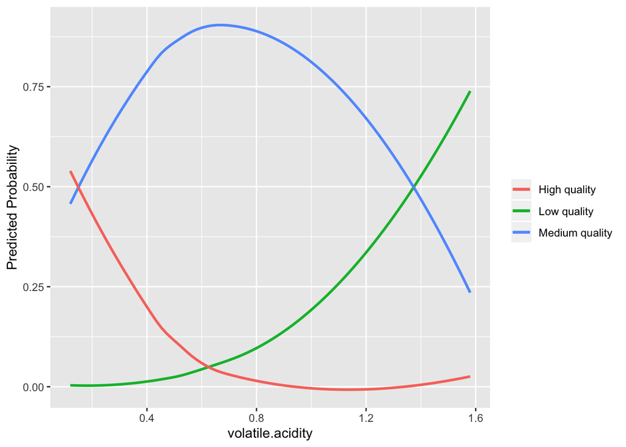

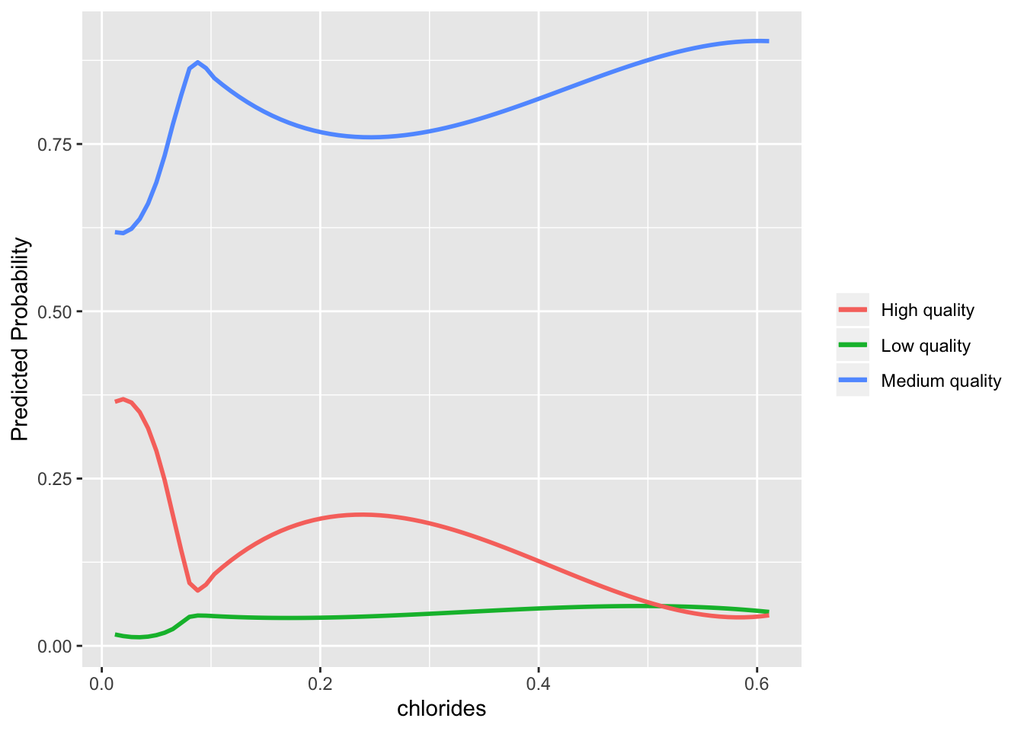

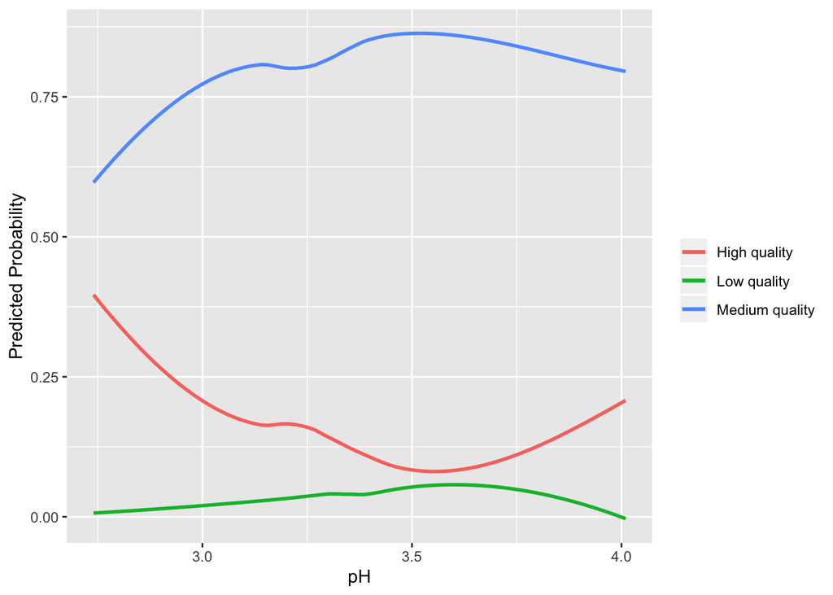

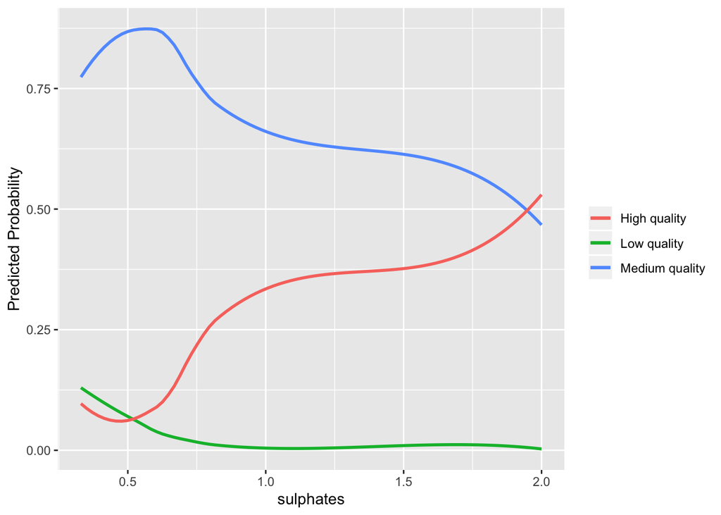

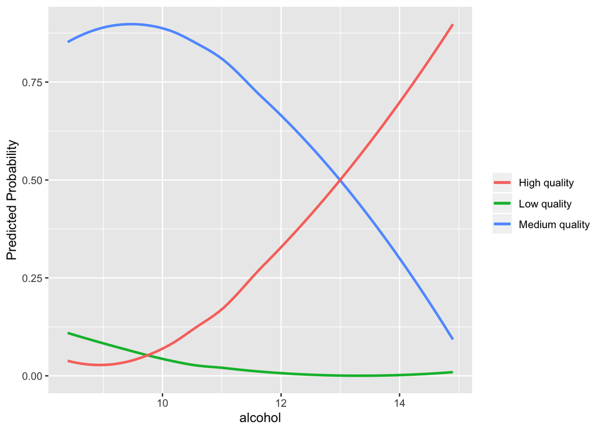

```r
for (i in c(2,5,9,10,11)){
  print(red %>% ggplot(aes_string(x=red[,i]))+
  geom_smooth(aes(y=fitted(omod2)[,1], color = "Low quality"), se = FALSE, method = 'loess')+
  geom_smooth(aes(y=fitted(omod2)[,2], color = "Medium quality"), se = FALSE,  method = 'loess')+
  geom_smooth(aes(y=fitted(omod2)[,3], color = "High quality"), se = FALSE,  method = 'loess')+
  xlab(colnames(red)[i])+
  ylab("Predicted Probability")+
  theme(legend.title = element_blank()))
}
```

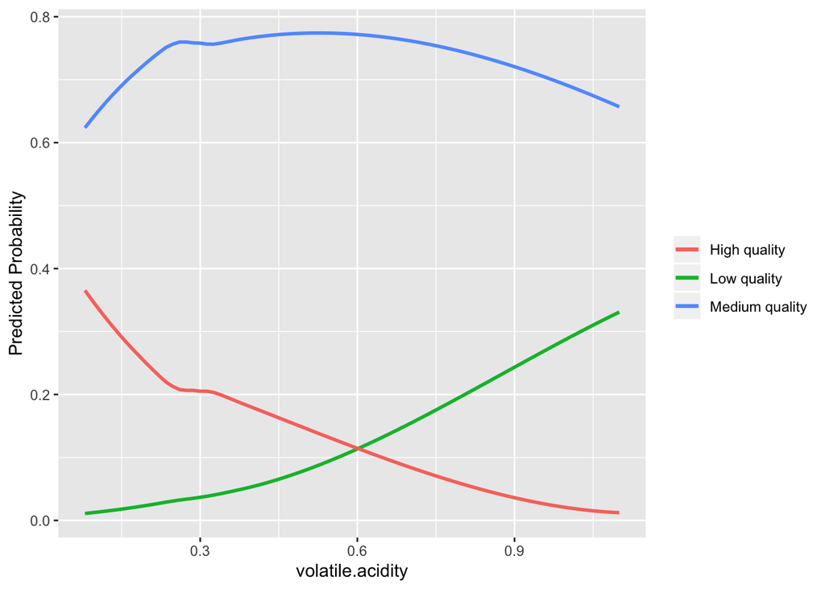

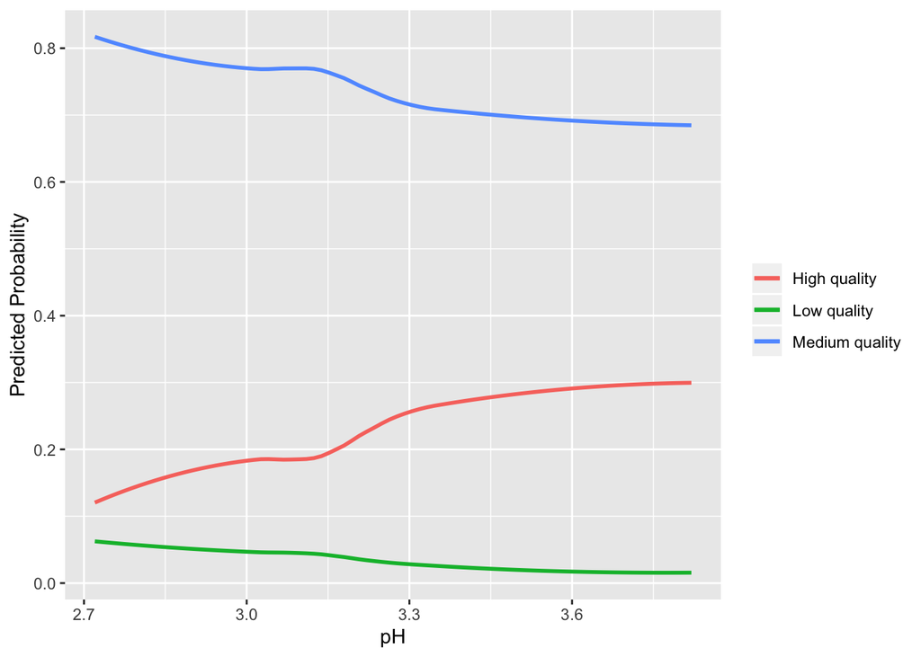

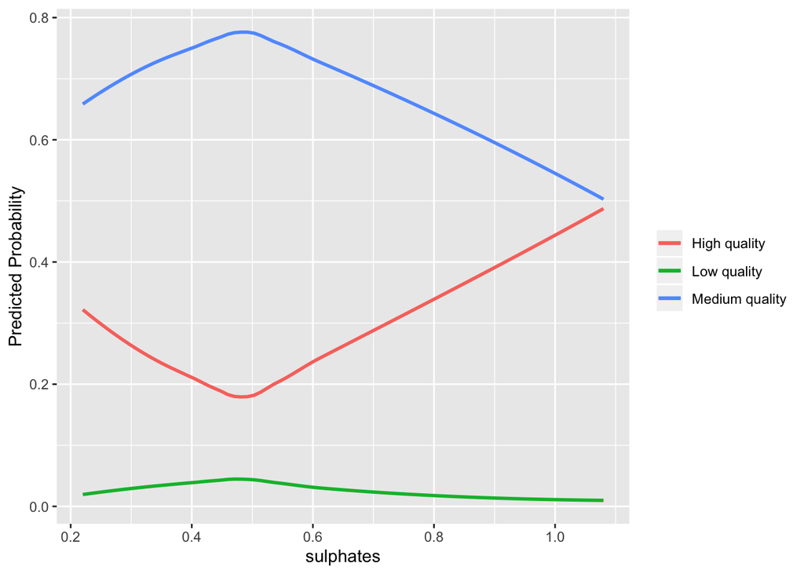

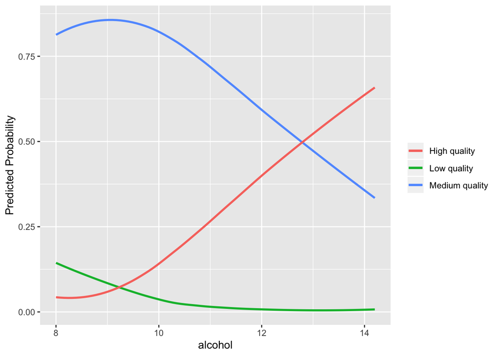

```r
for (i in c(2,9,10,11)){
  print(white %>% ggplot(aes(x=white[,i]))+
  geom_smooth(aes(y=fitted(omodww2)[,1], color = "Low quality"), se = FALSE, method = 'loess')+
  geom_smooth(aes(y=fitted(omodww2)[,2], color = "Medium quality"), se = FALSE,  method = 'loess')+
  geom_smooth(aes(y=fitted(omodww2)[,3], color = "High quality"), se = FALSE,  method = 'loess')+
  xlab(colnames(white)[i])+
  ylab("Predicted Probability")+
  theme(legend.title = element_blank()))
}
```

This chunk was purely for generating graphics for the website.

```r
#ggsave("volatred.png", width = 10, height = 8, units = "cm", dpi = 320)
```

### Monte Carlo for Average misclassification rates

Here we examined our misclassification rates for both red and white wines. We ran Monte Carlo simulations of 1000 iterations, each to get a more specific average misclassification rate for the two models.

```r
#Training and test data, Monte Carlo Red
monteRed <- vector("numeric", length = 1000)
for (i in 1:1000){
  set.seed(sample(1:99999, 1, replace = T))
trainingRows <- sample(1:nrow(red), 0.7 * nrow(red))
trainingData <- red[trainingRows, ]
testData <- red[-trainingRows, ]

options(contrasts = c("contr.treatment", "contr.poly"))
polrMod <- polr(as.factor(qualcat) ~ volatile.acidity+chlorides+sulphates + alcohol + pH, data=trainingData)

predictedClass <- predict(polrMod, testData)
predictedScores <- predict(polrMod, testData, type="p")

monteRed[i] <- (mean(as.character(testData$qualcat) != as.character(predictedClass)))
}

summary(monteRed)
```

```
##    Min. 1st Qu.  Median    Mean 3rd Qu.    Max.
##  0.1187  0.1500  0.1604  0.1605  0.1708  0.2083
```

```r
table(testData$qualcat, predictedClass)
```

```
##    predictedClass
##       1   2   3
##   1   0  19   0
##   2   0 393   6
##   3   0  44  18
```

```r
#Training and test data, Monte Carlo White
monteWhite <- vector("numeric", length = 1000)
for (i in 1:1000){
  set.seed(sample(1:99999, 1, replace = T))
trainingRows <- sample(1:nrow(white), 0.7 * nrow(white))
trainingData <- white[trainingRows, ]
testData <- white[-trainingRows, ]

options(contrasts = c("contr.treatment", "contr.poly"))
polrMod <- polr(as.factor(qualcat) ~ volatile.acidity+sulphates + alcohol + pH, data=trainingData)

predictedClass <- predict(polrMod, testData)
predictedScores <- predict(polrMod, testData, type="p")

monteWhite[i] <- (mean(as.character(testData$qualcat) != as.character(predictedClass)))
}

summary(monteWhite)
```

```
##    Min. 1st Qu.  Median    Mean 3rd Qu.    Max.
##  0.2163  0.2374  0.2439  0.2440  0.2510  0.2741
```

```r
table(testData$qualcat, predictedClass)
```

```
##    predictedClass
##        1    2    3
##   1    0   52    0
##   2    0 1052   40
##   3    0  262   64
```

Finally, we looked at the densities of the Monte carol simulation outputs and look at the proportion of high, average, and low quality wine observations for each data set to assess another reason for why our model performs so poorly for high and low quality wines. Ultimately, it was likely a combination of lacking a large number of predictors and low representation of high and low quality wines in each data set that led to high misclassification rates.

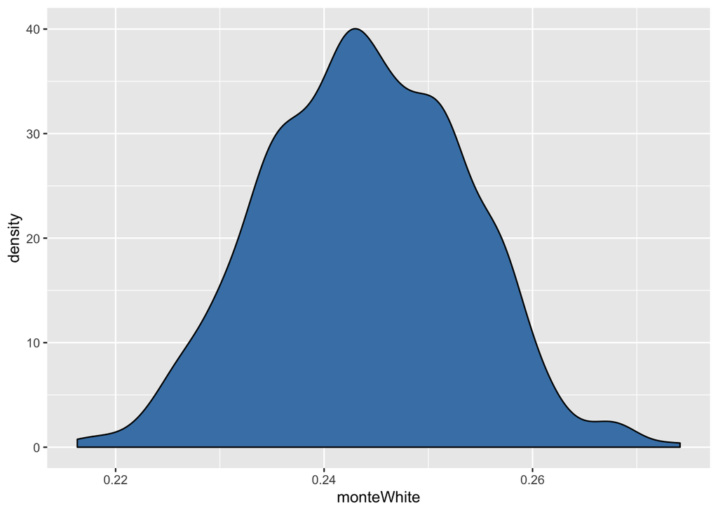

```r
ggplot()+
  geom_density(aes(x=monteWhite), fill = "steel blue")
```

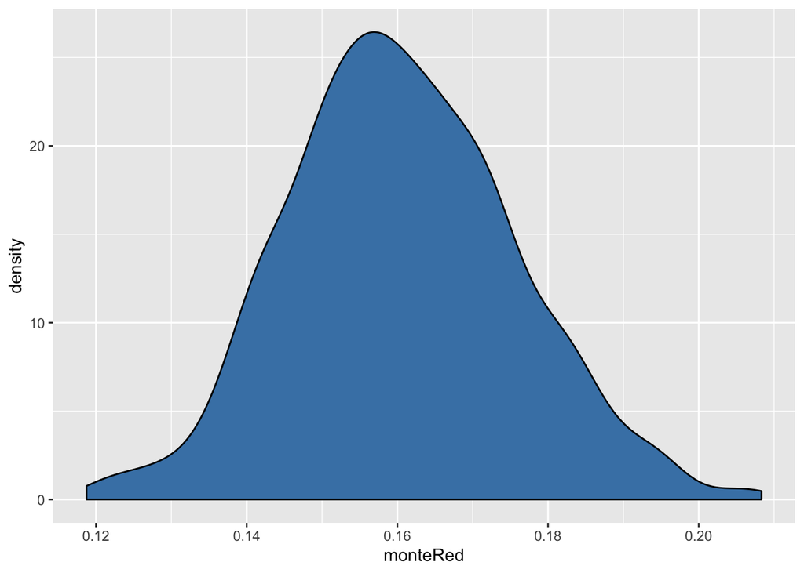

```r
ggplot()+
  geom_density(aes(x=monteRed), fill = "steel blue")
```

```r
tableWhites <- table(white$qualcat)
tableReds <- table(red$qualcat)
tableWhites
```

```
##
##    1    2    3
##  183 3655 1060
```

```r
tableReds
```

```
##
##    1    2    3
##   63 1319  217
```

```r
as.vector(tableWhites)
```

```
## [1]  183 3655 1060
```

```r
proptableWhites = c(tableWhites[1]/sum(tableWhites), tableWhites[2]/sum(tableWhites), tableWhites[3]/sum(tableWhites))

as.vector(tableReds)
```

```
## [1]   63 1319  217
```

```r
proptableReds = c(tableReds[1]/sum(tableReds), tableReds[2]/sum(tableReds), tableReds[3]/sum(tableReds))

proptableReds
```

```
##          1          2          3
## 0.03939962 0.82489056 0.13570982
```

```r
proptableWhites
```

```
##          1          2          3
## 0.03736219 0.74622295 0.21641486
```

# MACHINE LEARNING APPROACHES

## RANDOM FOREST

Summary: Decision trees are often used as decision support, where each node is a test (e.g. is alcohol proof below or above 10%), and each branch represents the outcome of this test. To construct a random forests we used 500 trees per forest, with trees created by randomly choose three features of the wine (e.g. pH, sugar levels and alcohol proof) . Each tree in the forest will classify the wine as good or bad quality, and the most common prediction of the trees across the forest is the classification which will be assigned.The error rate (called out of bag error), is estimated by testing our tree decisions on the samples which were not included to create the decision trees.

load packages

```r
library(randomForest)
require(caTools)
library(tidyr)
library(dplyr)
```

The code which was orgiginally used to divide quality into bad, average and good have been the code below to divide it up into three categories, but we decided for two

red_high_qual$quality[red_high_qual$quality<=5]<-0 red_high_qual$quality[red_high_qual$quality>5& red$quality<=6]<-1 red_high_qual$quality[red_high_qual$quality>6]<-2

Summary reds: We analysed over 1,500 red wines. For red wine, The most important predictor is also alcohol percentage, where higher alcohol levels are associated with higher quality ratings. The second most important predictor is sulfate levels. Our analysis found higher levels of sulfates are associated with higher quality scores. Wine labels in the US are required to have sulfite information on the label. Interestingly, wines that are less acidic require more sulfite to preserve, and sweeter wines tend to have more sulfites. Feel free to go to our website (Wine recommendation station) to look at some recommendations with these key words (e.g. sweetness is an indicator of sulfite levels) on our wine recommendation page.

```r
#Come up with cut-off for when wine is good
#greater than 6=  good wine
library(ggplot2)

#red%>% filter(quality>=6)#around 855 good quality wines

red_high_qual<- red#reassinging the same values tot new name in case something goes wrong

red_high_qual$quality[red_high_qual$quality<6]<-0#zero is bad /below average
red_high_qual$quality[red_high_qual$quality>=6]<-1#1 is good/above average


#summary(red_high_qual)
red_high_qual$quality<-as.factor(red_high_qual$quality)#transforming into factor

#can see wiith summary comman that it quality catetgories are now one and zero
summary(red_high_qual)#can look at ss
```

```
##  fixed.acidity   volatile.acidity  citric.acid    residual.sugar
##  Min.   : 4.60   Min.   :0.1200   Min.   :0.000   Min.   : 0.900
##  1st Qu.: 7.10   1st Qu.:0.3900   1st Qu.:0.090   1st Qu.: 1.900
##  Median : 7.90   Median :0.5200   Median :0.260   Median : 2.200
##  Mean   : 8.32   Mean   :0.5278   Mean   :0.271   Mean   : 2.539
##  3rd Qu.: 9.20   3rd Qu.:0.6400   3rd Qu.:0.420   3rd Qu.: 2.600
##  Max.   :15.90   Max.   :1.5800   Max.   :1.000   Max.   :15.500
##    chlorides       free.sulfur.dioxide total.sulfur.dioxide    density
##  Min.   :0.01200   Min.   : 1.00       Min.   :  6.00       Min.   :0.9901
##  1st Qu.:0.07000   1st Qu.: 7.00       1st Qu.: 22.00       1st Qu.:0.9956
##  Median :0.07900   Median :14.00       Median : 38.00       Median :0.9968
##  Mean   :0.08747   Mean   :15.87       Mean   : 46.47       Mean   :0.9967
##  3rd Qu.:0.09000   3rd Qu.:21.00       3rd Qu.: 62.00       3rd Qu.:0.9978
##  Max.   :0.61100   Max.   :72.00       Max.   :289.00       Max.   :1.0037
##        pH          sulphates         alcohol      quality    qualcat
##  Min.   :2.740   Min.   :0.3300   Min.   : 8.40   0:744   Min.   :1.000
##  1st Qu.:3.210   1st Qu.:0.5500   1st Qu.: 9.50   1:855   1st Qu.:2.000
##  Median :3.310   Median :0.6200   Median :10.20           Median :2.000
##  Mean   :3.311   Mean   :0.6581   Mean   :10.42           Mean   :2.096
##  3rd Qu.:3.400   3rd Qu.:0.7300   3rd Qu.:11.10           3rd Qu.:2.000
##  Max.   :4.010   Max.   :2.0000   Max.   :14.90           Max.   :3.000
##       bin3            bin23
##  Min.   :0.0000   Min.   :0.0000
##  1st Qu.:0.0000   1st Qu.:1.0000
##  Median :0.0000   Median :1.0000
##  Mean   :0.1357   Mean   :0.9606
##  3rd Qu.:0.0000   3rd Qu.:1.0000
##  Max.   :1.0000   Max.   :1.0000
```

```r
#check that they are in the right data class
sapply(red_high_qual, class)
```

```
##        fixed.acidity     volatile.acidity          citric.acid
##            "numeric"            "numeric"            "numeric"
##       residual.sugar            chlorides  free.sulfur.dioxide
##            "numeric"            "numeric"            "numeric"
## total.sulfur.dioxide              density                   pH
##            "numeric"            "numeric"            "numeric"
##            sulphates              alcohol              quality
##            "numeric"            "numeric"             "factor"
##              qualcat                 bin3                bin23
##            "numeric"            "numeric"            "numeric"
```

```r
#make good vs bad quality a factor
red_high_qual<- transform(red_high_qual, quality= as.factor(quality))# change quality to category eithere good or bad.


#check for na's, no Na's
#colSums(is.na(red_high_qual))
#summary(red_high_qual)
```

We were initially deciding between a cut-off of six for good wine and a cutoff of seven. We ultimately chose six because that is above average. This gives us 855 good quality red wines that we either use to train or test our random forest with.

We make sure to have both training and testing data, to avoid over-fitting. We use 75% of the wines to train and 25% to test our random forests and see how well our models can predict a good quality wine from a bad one, when the chemical information is available.

```r
#set a portion of data aside
sample_red= sample.split(red_high_qual$quality, SplitRatio = 0.75)#75% traiinnig
train_red= subset(red_high_qual, sample_red ==TRUE)
test_red= subset(red_high_qual, sample_red ==FALSE)#25% testing

#Below you ccan see the distribution for number of wines in testing and wines in training set
dim(train_red)
```

```
## [1] 1199   15
```

```r
dim(test_red)
```

```
## [1] 400  15
```

As you can see we use 1,199 red wines to train and 400 red wines to test our prediction with random forest.

With random forest we want to predict quality of the red wine, with the below parameters. Ntree parameters defines the numbers of trees to be generated, ideally want to generate them so that the out of bucket estimate of error rate is low( we build it with 500 trees, which is the default but also leads to high prediction accuracy in our case). The Mtry parameter indicates how many features are randomly chosen per tree (we chose three) to determine quality. We also indicate that we want to calculate the importance parameter allows us to calculate the importance of the variable in predicting the variable later on.

```r
rf_red <- randomForest( quality ~ fixed.acidity+volatile.acidity+ citric.acid+ residual.sugar+ chlorides + free.sulfur.dioxide + total.sulfur.dioxide + pH +sulphates + alcohol, data= train_red,  importance=T)
```

We can see below that the number of trees are 500, for which it randomly chooses three of the wine characteristics to determine the quality. The out-of-bag samples (wine samples left out), will be checked to see how they are classified giving us the below predictions.

```r
rf_red
```

```
##
## Call:
##  randomForest(formula = quality ~ fixed.acidity + volatile.acidity +      citric.acid + residual.sugar + chlorides + free.sulfur.dioxide +      total.sulfur.dioxide + pH + sulphates + alcohol, data = train_red,      importance = T)
##                Type of random forest: classification
##                      Number of trees: 500
## No. of variables tried at each split: 3
##
##         OOB estimate of  error rate: 19.77%
## Confusion matrix:
##     0   1 class.error
## 0 446 112   0.2007168
## 1 125 516   0.1950078
```

```r
#open jpeg file
jpeg("red_features.jpg", width=700, height=350)

varImpPlot(rf_red,main="Features for predicting good red wine")


#close file
dev.off()
```

[figure not shown]

```r
varImpPlot(rf_red, main="Features for predicting good white wine")
```

In red wine we also see that higher levels of alcohol are indicate of quality scores. Increases in sulfates increased quality scores for one. Low levels of volatile acidity were preferred, a good reminder to give your red wine a sniff, when you are ordering by the glass. If it smells too sour, a bit like vinegar you are probably better off ordering a different one. Total sulfur dioxide levels are preferred.Finally high levels of chlorides were indicative of low quality scores.

Information about the two feature importance is determined. The first feature (Mean Decrease Accuracy), reflects the decrease in performance that would occur if we would not have information on this variable. Hence the alcohol %, level of sulfates, volatile acidity and total sulfur dioxide are important in predicting wine quality.

We now want to see how well the prediction works for our testing data. When using random forest to predict whether the wine will be classified as good quality or bad quality, the prediction is made by the mean prediction of all the trees in the random forest.

```r
pred_red= predict(rf_red, test_red[-12])
cm_red= table(test_red[,12], pred_red)

cm_red
```

```
##    pred_red
##       0   1
##   0 149  37
##   1  32 182
```

WHITE WINE RANDOM FOREST

We analyzed the chemical composition of nearly 5,000 white wines to determine what chemical features are the best predictors of quality. The most important predictor is alcohol percentage, where higher alcohol levels are associated with higher quality ratings. Alcohol % can be found on the wine menu or on the back of the wine bottle when you are shopping.The second most important predictor is volatile acidity where lower levels are indicative of higher quality. The most common volatile acid in wine is acetic acid, which smells and tastes like vinegar.The third most important predictor is sulfur dioxide, when smelling your wine this can smell smokey , citrusy or like coffee . Feel free to use these descriptors on our wine recommendation page. Now to the code:

```r
#white%>% filter(quality>=6)#around 855 good quality wines

white_high_qual<- white

white_high_qual$quality[white$quality<6]<-0
white_high_qual$quality[white$quality>=6]<-1



head(white_high_qual)
```

```
##   fixed.acidity volatile.acidity citric.acid residual.sugar chlorides
## 1           7.0             0.27        0.36           20.7     0.045
## 2           6.3             0.30        0.34            1.6     0.049
## 3           8.1             0.28        0.40            6.9     0.050
## 4           7.2             0.23        0.32            8.5     0.058
## 5           7.2             0.23        0.32            8.5     0.058
## 6           8.1             0.28        0.40            6.9     0.050
##   free.sulfur.dioxide total.sulfur.dioxide density   pH sulphates alcohol
## 1                  45                  170  1.0010 3.00      0.45     8.8
## 2                  14                  132  0.9940 3.30      0.49     9.5
## 3                  30                   97  0.9951 3.26      0.44    10.1
## 4                  47                  186  0.9956 3.19      0.40     9.9
## 5                  47                  186  0.9956 3.19      0.40     9.9
## 6                  30                   97  0.9951 3.26      0.44    10.1
##   quality qualcat bin3 bin23
## 1       1       2    0     1
## 2       1       2    0     1
## 3       1       2    0     1
## 4       1       2    0     1
## 5       1       2    0     1
## 6       1       2    0     1
```

```r
summary(white_high_qual)
```

```
##  fixed.acidity    volatile.acidity  citric.acid     residual.sugar
##  Min.   : 3.800   Min.   :0.0800   Min.   :0.0000   Min.   : 0.600
##  1st Qu.: 6.300   1st Qu.:0.2100   1st Qu.:0.2700   1st Qu.: 1.700
##  Median : 6.800   Median :0.2600   Median :0.3200   Median : 5.200
##  Mean   : 6.855   Mean   :0.2782   Mean   :0.3342   Mean   : 6.391
##  3rd Qu.: 7.300   3rd Qu.:0.3200   3rd Qu.:0.3900   3rd Qu.: 9.900
##  Max.   :14.200   Max.   :1.1000   Max.   :1.6600   Max.   :65.800
##    chlorides       free.sulfur.dioxide total.sulfur.dioxide    density
##  Min.   :0.00900   Min.   :  2.00      Min.   :  9.0        Min.   :0.9871
##  1st Qu.:0.03600   1st Qu.: 23.00      1st Qu.:108.0        1st Qu.:0.9917
##  Median :0.04300   Median : 34.00      Median :134.0        Median :0.9937
##  Mean   :0.04577   Mean   : 35.31      Mean   :138.4        Mean   :0.9940
##  3rd Qu.:0.05000   3rd Qu.: 46.00      3rd Qu.:167.0        3rd Qu.:0.9961
##  Max.   :0.34600   Max.   :289.00      Max.   :440.0        Max.   :1.0390
##        pH          sulphates         alcohol         quality
##  Min.   :2.720   Min.   :0.2200   Min.   : 8.00   Min.   :0.0000
##  1st Qu.:3.090   1st Qu.:0.4100   1st Qu.: 9.50   1st Qu.:0.0000
##  Median :3.180   Median :0.4700   Median :10.40   Median :1.0000
##  Mean   :3.188   Mean   :0.4898   Mean   :10.51   Mean   :0.6652
##  3rd Qu.:3.280   3rd Qu.:0.5500   3rd Qu.:11.40   3rd Qu.:1.0000
##  Max.   :3.820   Max.   :1.0800   Max.   :14.20   Max.   :1.0000
##     qualcat           bin3            bin23
##  Min.   :1.000   Min.   :0.0000   Min.   :0.0000
##  1st Qu.:2.000   1st Qu.:0.0000   1st Qu.:1.0000
##  Median :2.000   Median :0.0000   Median :1.0000
##  Mean   :2.179   Mean   :0.2164   Mean   :0.9626
##  3rd Qu.:2.000   3rd Qu.:0.0000   3rd Qu.:1.0000
##  Max.   :3.000   Max.   :1.0000   Max.   :1.0000
```

```r
#check that they are in the right data class
sapply(white_high_qual, class)
```

```
##        fixed.acidity     volatile.acidity          citric.acid
##            "numeric"            "numeric"            "numeric"
##       residual.sugar            chlorides  free.sulfur.dioxide
##            "numeric"            "numeric"            "numeric"
## total.sulfur.dioxide              density                   pH
##            "numeric"            "numeric"            "numeric"
##            sulphates              alcohol              quality
##            "numeric"            "numeric"            "numeric"
##              qualcat                 bin3                bin23
##            "numeric"            "numeric"            "numeric"
```

```r
#make good vs bad quality a factor
white_high_qual<- transform(white_high_qual, quality= as.factor(quality))

#check for na's, no Na's
#colSums(is.na(white_high_qual))
```

```r
#set a portion of data aside
sample_white= sample.split(white_high_qual$quality, SplitRatio = 0.75)

train_white= subset(white_high_qual, sample_white ==TRUE)
test_white= subset(white_high_qual, sample_white ==FALSE)

dim(train_white)
```

```
## [1] 3674   15
```

```r
dim(test_white)
```

```
## [1] 1224   15
```

```r
rf_white <- randomForest( quality ~ fixed.acidity+volatile.acidity+ citric.acid+ residual.sugar+ chlorides+ free.sulfur.dioxide + total.sulfur.dioxide + pH +sulphates + alcohol, data= train_white, importance= T)

rf_white
```

```
##
## Call:
##  randomForest(formula = quality ~ fixed.acidity + volatile.acidity +      citric.acid + residual.sugar + chlorides + free.sulfur.dioxide +      total.sulfur.dioxide + pH + sulphates + alcohol, data = train_white,      importance = T)
##                Type of random forest: classification
##                      Number of trees: 500
## No. of variables tried at each split: 3
##
##         OOB estimate of  error rate: 16.03%
## Confusion matrix:
##     0    1 class.error
## 0 859  371  0.30162602
## 1 218 2226  0.08919804
```

```r
#pred_white= predict(rf_white, newdata= test_white)
```

```r
#open jpeg file
jpeg("white_features.jpg", width=700, height=350)

#create plot
varImpPlot(rf_white, main="Features for predicting good white wine")

#close file
dev.off()
```

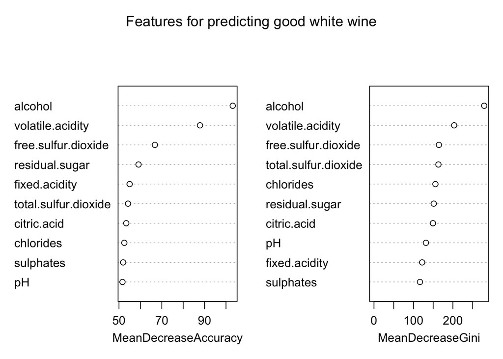

```r
varImpPlot(rf_white, main="Features for predicting good white wine")
```

For white wine we can see that the most important characteristics are alcohol content, volatile acidity, the amount of sulfur (both free and total), and the amount of chlorides.Low chloride levels are preferred, increases in free sulfur dioxide are indicative of better ratings but low levels of total sulfur dioxide were preferred.

Generally for white wine higher alcohol content was indicative of higher scores, low volatile acidity, increases taste with higher free sulfur dioxide levels, but lower ratings with increase in total sulfur dioxides. Wines with low chloride levels were preferred.

```r
pred_white= predict(rf_white, test_white[-12])
cm_white= table(test_white[,12], pred_white)

cm_white
```

```
##    pred_white
##       0   1
##   0 289 121
##   1  79 735
```

To improve our analysis in the future we can look whether the trend holds across different data sets.